# Assignment 5: Generalized Linear Models and Clustering

Victoria S.

2025-11-20

## Generalized Linear Model

I will be using raster data from Salt Lake City to create and fit a model that shows how well different variables explain urban change in the area. The code is from Dr. Van Berkel and model interpretation is done by myself.

First, I loaded in necessary libraries and the datasets. Then I combined all the individual rasters into one raster stack which was then converted into a data frame.

```r
library(terra)
library(tidyverse)
library(leaflet)
library(ROCR)
library(plyr)
library(reshape2)
library(plotly)

#first import the land cover/use data
NLCD_2001 <- rast("NLCD_2001_SL.tif")
NLCD_2004 <- rast("NLCD_2004_SL.tif")
NLCD_2006 <- rast("NLCD_2006_SL.tif")
NLCD_2008 <- rast("NLCD_2008_SL.tif")
NLCD_2011 <- rast("NLCD_2011_SL.tif")
NLCD_2013 <- rast("NLCD_2013_SL.tif")
NLCD_2016 <- rast("NLCD_2016_SL.tif")
# Distance to parks and protected areas in km (Euclidian) for the study area
Park_dist <- rast("Parks_dist_SL.tif")
# Road density for a 1 km neighborhood
Rd_dns1km <- rast("Rd_dns1km_SL.tif")
# Distance to water bodies in km (Euclidean)
WaterDist <- rast("WaterDist_SL.tif")
# elevation
DEM <- rast("DEM_SL.tif")

allrasters <- c(NLCD_2001, NLCD_2004, NLCD_2006, NLCD_2008, NLCD_2011, NLCD_2013, NLCD_2016, Park_dist, Rd_dns1km, WaterDist,DEM)

allrastersSL <- as.data.frame(allrasters, xy=TRUE)
## Here we are filtering out the no data values (stored as 128)
allrastersSL <- allrastersSL %>%
  filter (NLCD_2001_SL != 128)
```

Next, all the pixels whose cover class value changed to urban any time from 2001 to 2016 were found.

```r
allrastersSL <- allrastersSL %>%
    mutate(urbanChg = (NLCD_2001_SL != 21 & NLCD_2001_SL != 22 & NLCD_2001_SL != 23 & NLCD_2001_SL != 24) &  (NLCD_2016_SL == 21 | NLCD_2016_SL == 22  | NLCD_2016_SL == 23 | NLCD_2016_SL == 24))
```

Then, a random sample of the data was taken. A generalized linear model was then fit to the data. Values important to assessing the fit of the model were generated, including the coefficients, z values, ROC, and AUC.

```r
SL <- allrastersSL %>%
  filter(NLCD_2001_SL != 21 & NLCD_2001_SL != 22 & NLCD_2001_SL != 23 & NLCD_2001_SL != 24)
SL <- SL[10:14]
SLmelt<-melt(SL)
###Grab all the developed cells (presence)
newUrban <- SL %>%
  filter(urbanChg == TRUE)

###Grab all the nondeveloped and not previously urban cells (absence)
nonUrban <- SL %>%
  filter(urbanChg == FALSE)

###Get a random sample of the absence data
### that is twice as large as the presence data
index <- sample(1:nrow(nonUrban), (round(nrow(newUrban)* 2)))
SLsampleUrban <- nonUrban[index, ]

### combine the orginal presence and absence data
SLsample <- cbind(SLsampleUrban, newUrban)

###Consider a train and testing sample by futher subsampling the data
index <- sample(1:nrow(SL), (round(nrow(SL)* 0.01)))
SLsample <- SL[index, ]


fit <- glm(urbanChg ~ Parks_dist_SL + Rd_dns1km_SL + WaterDist_SL + DEM_SL,data=SLsample,family=binomial())
summary(fit)
```

```
##
## Call:
## glm(formula = urbanChg ~ Parks_dist_SL + Rd_dns1km_SL + WaterDist_SL +
##     DEM_SL, family = binomial(), data = SLsample)
##
## Coefficients:
##                 Estimate Std. Error z value Pr(>|z|)
## (Intercept)    2.483e+00  4.766e-01   5.210 1.88e-07 ***
## Parks_dist_SL  1.110e-04  9.936e-06  11.171  < 2e-16 ***
## Rd_dns1km_SL   1.711e+01  5.267e-01  32.480  < 2e-16 ***
## WaterDist_SL   2.610e-04  4.535e-05   5.756 8.63e-09 ***
## DEM_SL        -5.194e-03  3.561e-04 -14.588  < 2e-16 ***
## ---
## Signif. codes:  0 '***' 0.001 '**' 0.01 '*' 0.05 '.' 0.1 ' ' 1
##
## (Dispersion parameter for binomial family taken to be 1)
##
##     Null deviance: 7820.9  on 16616  degrees of freedom
## Residual deviance: 3872.2  on 16612  degrees of freedom
## AIC: 3882.2
##
## Number of Fisher Scoring iterations: 9
```

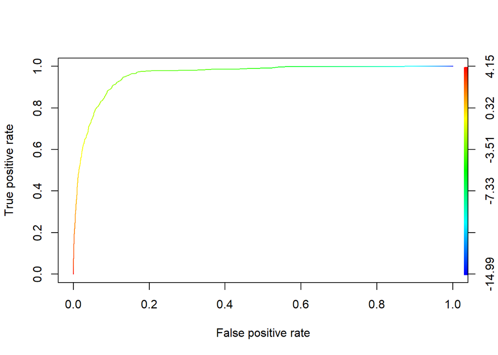

```r
## Loading required package: gplots

# plot a ROC curve for a single prediction run
# and color the curve according to cutoff.
pred <- prediction(predict(fit), SLsample$urbanChg)
perf <- performance(pred,"tpr","fpr")
plot(perf,colorize=TRUE)
```

```r
## A simpler way to understand these result is to calculate the
## area under the curve(AUC). The closer this number is to 1, the
## better your model fit
auc_ROCR <- performance(pred, measure = "auc")
auc_ROCR <- auc_ROCR@y.values[[1]]
auc_ROCR
```

```
## [1] 0.9590521
```

Taking all of these values into account, we are able to see that the model does a very good job at explaining urban change in Salt Lake City. As distance to parks/water and road density increase, the likelihood that an area will be developed also increases. As elevation increases, the likelihood that an area will be developed decreases. Other variables that I would add to the model to better explain urban development would be distance to schools or distance to grocery stores. I hypothesize that as distance to schools or grocery stores decrease, the likelihood that an area will be developed increases.

## Cluster Analysis

For my cluster analysis, I was interested in visualizing clusters with similar outdoor recreation amenities.

I again first loaded in packages and data.

```r
library(fastcluster)
library(graphics)
library(ggplot2)
library(ggdendro)
library(sf)

amenData<- st_read("AmenDataAll.shp")
```

To find clusters with similar outdoor recreation amenities, I used variables for percent public lands, total length of hiking trails, and percent water bodies.

```r
st_geometry(amenData)
geomData = st_sfc(amenData$geometry)

amenDataDF<-amenData[,c("ser00publi", "HikeLength","WaterPct")]
amenDataDF <- na.omit(amenDataDF)
amenDataDF <- as.data.frame(amenDataDF)[1:3]
db_scaled <- scale(amenDataDF)
```

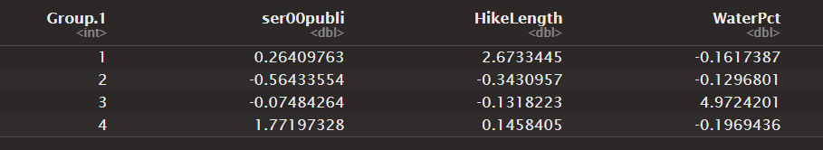

```r
# Determine number of clusters
wss <- (nrow(db_scaled)-1)*sum(apply(db_scaled,2,var))
for (i in 2:15) wss[i] <- sum(kmeans(db_scaled,
   centers=i)$withinss)
plot(1:15, wss, type="b", xlab="Number of Clusters",
  ylab="Within groups sum of squares")

fit <- kmeans(db_scaled, 4)

aggregate(db_scaled,by=list(fit$cluster),FUN=mean)

amenData <- data.frame(amenData, fit$cluster)

st_geometry(amenData) <- geomData
```

[output not shown]

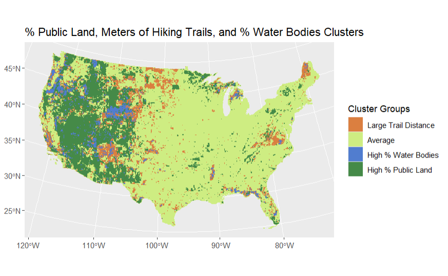

```r
amenData$cluster <- factor(amenData$fit.cluster, levels = 1:4)

cluster_colors <- c("#DB7F40", "#CEED82", "#517DCF", "#458A48")

ggplot() +
  geom_sf(data = amenData, aes(fill = as.factor(fit.cluster)), color = NA) +
  scale_fill_manual(
    name = "Cluster Groups",              # Legend title
    values = cluster_colors,          # Colors for each cluster
  ) +
  theme(legend.position = "right") +
  ggtitle("% Public Land, Meters of Hiking Trails, and % Water Bodies Clusters")
```

The four groups that were made from the k-means clustering placed areas into a group of either mostly average values across all three variables, or into a group with either higher than average % public lands, hiking trail distances, or % water bodies. The clusters generally make sense as there is a lot more public land in the western United States and this was seen in the clusters. There is likely a lot of overlap between areas with more public land and areas with greater distances of hiking trails. Most of the country was included in the average cluster. The water bodies cluster was surprising as there were pretty large areas in this cluster and most of the area was in the more arid western United States. I expected to see more areas with higher percents of water bodies in the eastern United States.